# Raport z eksperymentu

Wiktor Bagiński

## Opis przygotowanych eksperymentów

Przygotowałem cztery wykresy na podstawie ramki ranych “auta2012” z pakietu PogromcyDanych. Przedstawiają one średnią pojemność aut produkowanych przez marki “Chevrolet” oraz “Mercedes-Benz”. Jednak nie to jest przedmiotem naszego zainteresowania. Celem eksperymentu jest sprawdzenie czy osoby ankietowane będą zmieniać swoje odpowiedzi na temat wielkości danych zjawisk w zależności od tego czy wykresy pojemności będą obcięte na osi pojemności, czy będą zaczynały się od zera.

Wykresy obcięte na osi pojemności wyglądały tak:

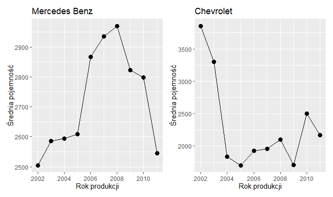

Wykresy pokazujące “cały” wykres prezentowały się natomiast tak:

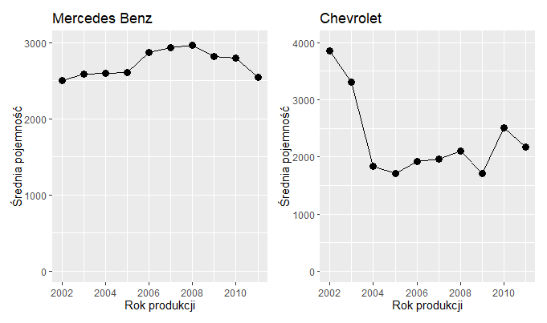

Jak można zauważyć wykresy na górze i na dole przedstawiają te same dane, jednak rozwiązujący ankiete nie dostali tej informacji “na tacy”. Pod obiema parami wykresów poproszeni zostali najpierw o zaznaczenie jednego zdania z którym się zgadzają. Ich opcje wyboru wyglądały następująco:

1. Auta marki Mercedes-Benz miały dużo większe zmiany w średniej pojemności, niż auta marki Chevrolet.
2. Auta marki Mercedes-Benz miały większe zmiany w średniej pojemności, niż auta marki Chevrolet.
3. Auta marki Mercedes-Benz podobne zmiany w średniej pojemności, niż auta marki Chevrolet.
4. Auta marki Mercedes-Benz miały mniejsze zmiany w średniej pojemności, niż auta marki Chevrolet.
5. Auta marki Mercedes-Benz miały dużo mniejsze zmiany w średniej pojemności, niż auta marki Chevrolet.

Zostało również postawione pytanie trzecie; “Które wykresy uznajesz za czytelniejsze?” Na to pytanie anietowani mogli wskazać wykresy pierwsze, wykresy drugie lub stwierdzić że oba wykresy były równie czytelne.

## Wyniki

### Pytanie pierwsze

```
Odpowiedzi na pytanie pierwsze prezentowały się w następujący sposób:
```

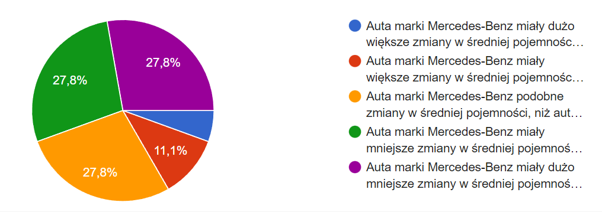

```
Jak dobrze widać odpowiedzi rozłożyły się mniej więcej po równo pomiędzy "Podobne", "mniejsze" oraz "dużo mniejsze".
```

### Pytanie drugie

```
Odpowiedzi na pytanie drugie prezentowały się w następujący sposób:
```

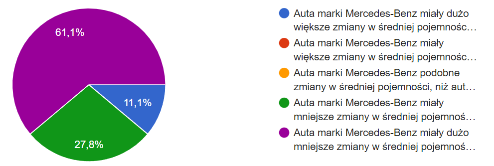

Tutaj praktycznie zniknąła opcja “podobne”, a wyraźnym zwyciezcą konkurs popularności okazał się wybór “dużo mniejsze”.

### Pytanie trzecie

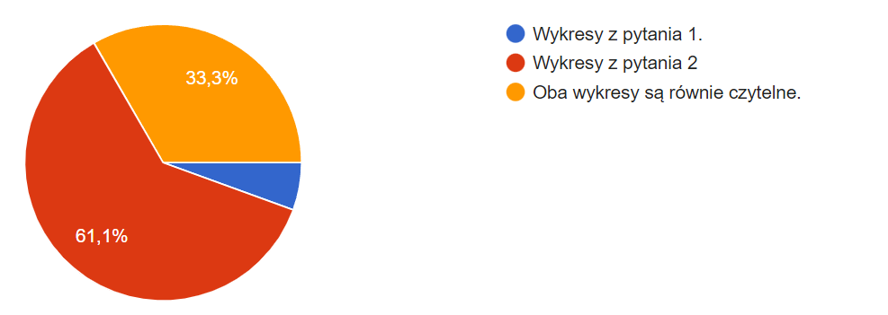

Większość osób wybrało opcję “Drugie wykresy są czytelniejsze”. Co ciekawe, osoby zaznaczające opcje inne niż ta najpopularniejsza, to zazwyczaj były te same osoby co w odpowiedzi na pytanie numer jeden zaznaczały odpowiedź “podobne”.

## Wnioski

Jak widać istotna grupa badanych osób nie zauważyła, że były to wykresy stworzone z tych samych danych. Wykresy zaczynające się od zera sprawiały, że osoby oceniały w ogólności sytacje dużo bardziej trafnie. Co więcej większośc przyznała, że wykresy z pytania drugiego oceniają na bardziej czytelne.